# Distribuzioni campionarie

Deviazione standard, varianza e differenza tra medie

Author

Matteo Manente

Published

26 May 2026

# Formule principali

In questo file consideriamo tre distribuzioni campionarie:

- distribuzione campionaria della **deviazione standard**;
- distribuzione campionaria della **varianza**;
- distribuzione campionaria della **differenza tra medie**.

| Distribuzione campionaria | Media | Errore Standard |
| --- | --- | --- |
| **Deviazione standard** | $E(s) = \sqrt{\frac{n-1}{n}} \times \sigma$ | $SE_s \approx \frac{\sigma}{\sqrt{2n}}$ |
| **Varianza** | $E(s^2) = \frac{n-1}{n} \times \sigma^2$ | $SE_{s^2} = \sigma^2 \sqrt{\frac{2(n-1)}{n^2}}$ |
| **Differenza tra medie** | $\mu_{\bar{x}_1 - \bar{x}_2} = \mu_1 - \mu_2$ | $SE_{\bar{x}_1 - \bar{x}_2} = \sqrt{\frac{\sigma_1^2}{n_1} + \frac{\sigma_2^2}{n_2}}$ |

# Grafici delle distribuzioni campionarie

## Distribuzione campionaria della deviazione standard

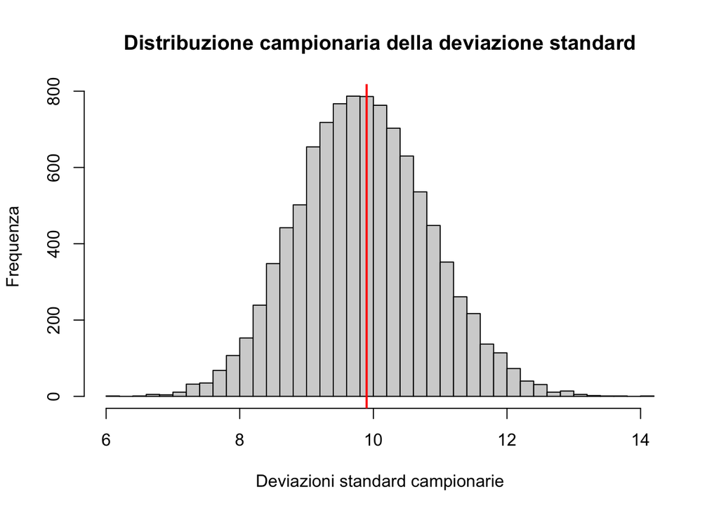

## Distribuzione campionaria della varianza

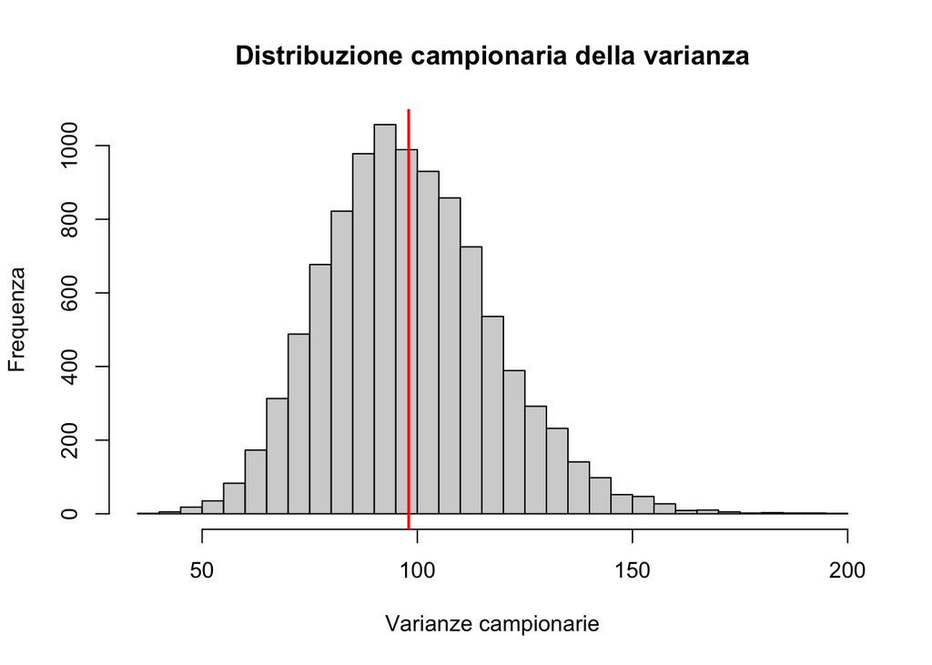

## Distribuzione campionaria della differenza tra medie

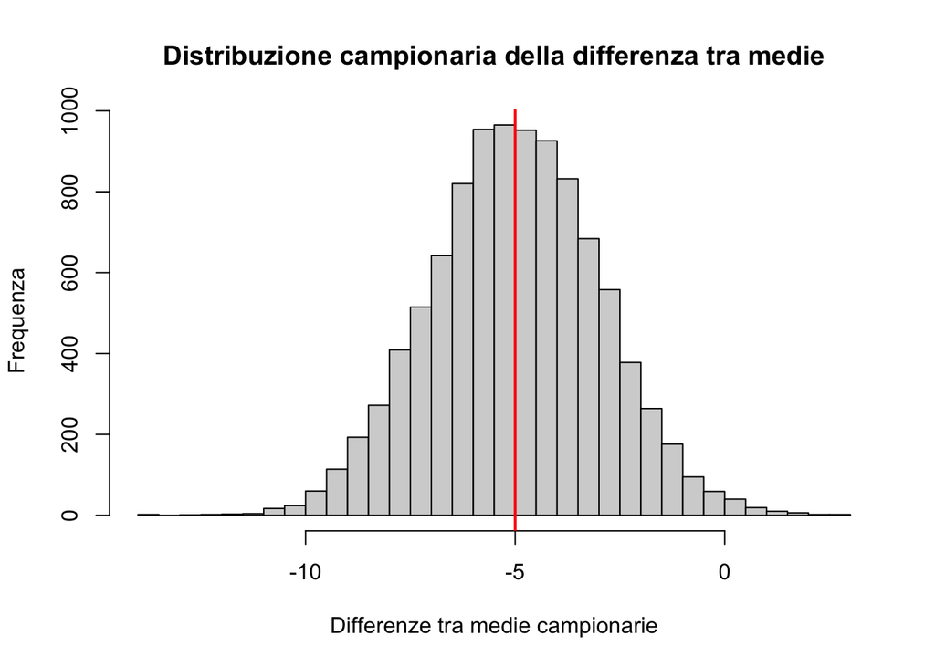

## Distribuzione campionaria della deviazione standard

La **distribuzione campionaria della deviazione standard** descrive come varia la deviazione standard calcolata su campioni diversi estratti dalla stessa popolazione.

Se estraessimo molti campioni della stessa numerosità e calcolassimo la deviazione standard in ciascun campione, otterremmo tanti valori diversi di $s$.

| Proprietà | Formula | Significato |
| --- | --- | --- |
| **Media** | $E(s) = \sqrt{\frac{n-1}{n}} \times \sigma$ | Il valore atteso della deviazione standard campionaria è leggermente inferiore alla deviazione standard della popolazione |
| **Errore Standard** | $SE_s \approx \frac{\sigma}{\sqrt{2n}}$ | Indica quanto variano le deviazioni standard campionarie da campione a campione |

### Esempio semplice

Se $\sigma = 10$ e $n = 50$:

## Distribuzione campionaria della varianza

La **distribuzione campionaria della varianza** descrive come varia la varianza calcolata su campioni diversi estratti dalla stessa popolazione.

Se estraessimo molti campioni della stessa numerosità e calcolassimo la varianza in ciascun campione, otterremmo tanti valori diversi di $s^2$.

| Proprietà | Formula | Significato |
| --- | --- | --- |
| **Media** | $E(s^2) = \frac{n-1}{n} \times \sigma^2$ | Il valore atteso della varianza campionaria è leggermente inferiore alla varianza della popolazione |
| **Errore Standard** | $SE_{s^2} = \sigma^2 \sqrt{\frac{2(n-1)}{n^2}}$ | Indica quanto variano le varianze campionarie da campione a campione |

### Esempio semplice

Se $\sigma = 10$ e $n = 50$:

$$E(s^2) = \frac{50-1}{50} \times 10^2$$

$$E(s^2) = \frac{49}{50} \times 100$$

$$E(s^2) = 98$$

## Distribuzione campionaria della differenza tra medie

La **distribuzione campionaria della differenza tra medie** descrive come varia la differenza tra due medie campionarie quando estraiamo ripetutamente due campioni da due popolazioni.

È utile quando vogliamo confrontare due gruppi, ad esempio un gruppo sperimentale e un gruppo di controllo.

| Proprietà | Formula | Significato |
| --- | --- | --- |
| **Media** | $\mu_{\bar{x}_1 - \bar{x}_2} = \mu_1 - \mu_2$ | La media della distribuzione campionaria della differenza tra medie è uguale alla vera differenza tra le due popolazioni |
| **Errore Standard** | $SE_{\bar{x}_1 - \bar{x}_2} = \sqrt{\frac{\sigma_1^2}{n_1} + \frac{\sigma_2^2}{n_2}}$ | Indica quanto varia la differenza tra medie campionarie da campione a campione |

### Esempio semplice

Se:

$$\mu_1 = 100$$

e:

$$\mu_2 = 105$$

allora:

$$\mu_{\bar{x}_1 - \bar{x}_2} = 100 - 105 = -5$$

# Nota importante

In questo file, per la deviazione standard e la varianza, abbiamo usato formule coerenti con quelle presentate nel corso.

In particolare, la varianza campionaria è calcolata con denominatore $n$:

$$s^2 = \frac{\sum (x_i - \bar{x})^2}{n}$$

Per questo motivo, nel codice R non abbiamo usato direttamente `var()` e `sd()`, perché in R queste funzioni usano il denominatore $n - 1$.